# Reproducible Research: Peer Assessment 1

## Loading and preprocessing the data

```r
library(tidyverse)
df_data <- read_csv(file = "activity/activity.csv")
```

## What is mean total number of steps taken per day?

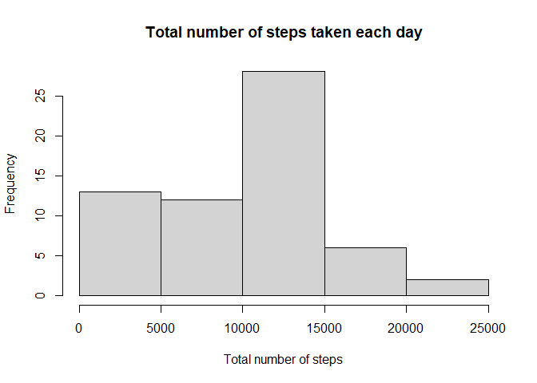

```r
# For this part of the assignment, you can ignore the missing values in the dataset.
# 1. Make a histogram of the total number of steps taken each day
# 2. Calculate and report the mean and median total number of steps taken per day

df_total_steps_per_day <- df_data %>%
  group_by(date) %>%
  summarise(total_steps_per_day = sum(steps, na.rm = TRUE))

hist(df_total_steps_per_day$total_steps_per_day, main = "Total number of steps taken each day", xlab = "Total number of steps")
```

> The mean total number of steps taken per day is : **9354**

> The median total number of steps taken per day is : **10395**

## What is the average daily activity pattern?

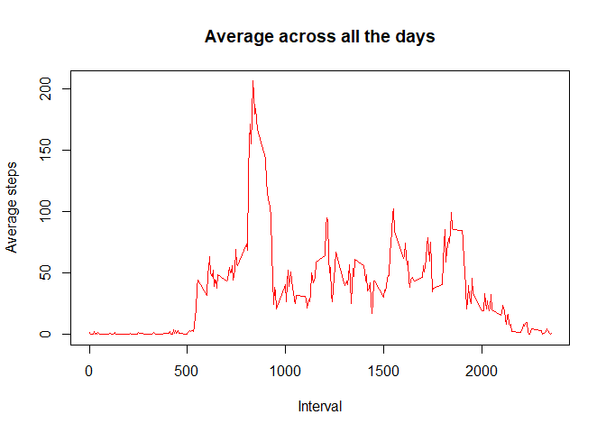

```r
df_average_steps_per_day_interval <-  df_data %>%
  group_by(interval) %>%
  summarise(average_steps_per_day_interval = mean(steps, na.rm = TRUE))

# create the plot
plot(df_average_steps_per_day_interval$interval, df_average_steps_per_day_interval$average_steps_per_day_interval,
     type = "l",  main = "Average across all the days", xlab = "Interval", ylab = "Average steps",
     col = "red", lwd =1)
```

```r
max_steps <- max(df_average_steps_per_day_interval$average_steps_per_day_interval)

interval_with_max <- df_average_steps_per_day_interval %>%
  filter(average_steps_per_day_interval == max_steps) %>%
  pull(interval)
```

The 5 minute interval with maximum number of steps is: **835**

## Imputing missing values

1. Calculate and report the total number of missing values in the dataset

Total number of rows with NAs: **2304**

2. Devise a strategy for filling in all of the missing values in the dataset. The strategy does not need to be sophisticated. For example, you could use the mean/median for that day, or the mean for that 5-minute interval, etc.

> Calculated the median for each interval to be used to update the dataset

```r
df_median_steps_per_interval <- df_data %>%
  group_by(interval) %>%
  summarise(interval_median = median(steps, na.rm = TRUE))
```

3. Create a new dataset that is equal to the original dataset but with the missing data filled in.

```r
df_filled_NAs <- df_data %>%
  mutate(steps = ifelse(is.na(steps), recode(interval, !!!setNames(df_median_steps_per_interval$interval_median, df_median_steps_per_interval$interval)), steps))

df_filled_NAs %>% DT::datatable()
```

|  | steps | date | interval |
| --- | --- | --- | --- |
| 1 | 0 | 01/10/2012 | 0 |
| 2 | 0 | 01/10/2012 | 5 |
| 3 | 0 | 01/10/2012 | 10 |
| 4 | 0 | 01/10/2012 | 15 |
| 5 | 0 | 01/10/2012 | 20 |
| 6 | 0 | 01/10/2012 | 25 |
| 7 | 0 | 01/10/2012 | 30 |
| 8 | 0 | 01/10/2012 | 35 |
| 9 | 0 | 01/10/2012 | 40 |
| 10 | 0 | 01/10/2012 | 45 |

[output cut: 17558 more lines]

4. Make a histogram of the total number of steps taken each day and Calculate and report the mean and median total number of steps taken per day. Do these values differ from the estimates from the first part of the assignment? What is the impact of imputing missing data on the estimates of the total daily number of steps?

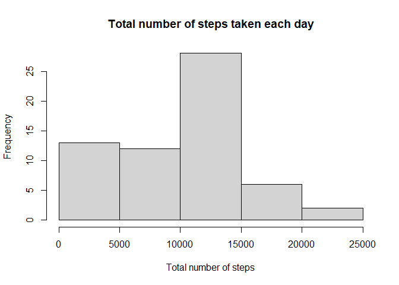

```r
df_updated_steps_per_day <- df_filled_NAs %>%
  group_by(date) %>%
  summarise(total_steps_per_day = sum(steps, na.rm = TRUE))

hist(df_updated_steps_per_day$total_steps_per_day, main = "Total number of steps taken each day", xlab = "Total number of steps")
```

> The mean total number of steps taken per day is : **9504**

> The median total number of steps taken per day is : **10395**

> The mean total number of days increased after imputing missing values by: **150**

## Are there differences in activity patterns between weekdays and weekends?

1. Create a new factor variable in the dataset with two levels – “weekday” and “weekend” indicating whether a given date is a weekday or weekend day.

```r
df_data_with_weekday <- df_filled_NAs %>%
  mutate(weekd = weekdays(as.Date(date)),
         weekday = ifelse(weekd %in% c("Saturday", "Sunday"), "weekend", "weekday"),
         weekday = factor(weekday))
```

2. Make a panel plot containing a time series plot (i.e. type = “l”) of the 5-minute interval (x-axis) and the average number of steps taken, averaged across all weekday days or weekend days (y-axis)

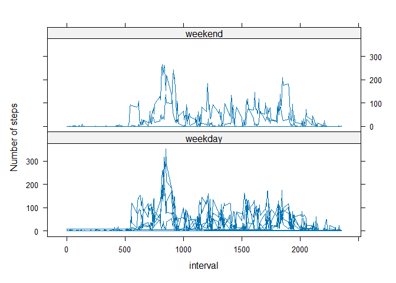

```r
df_average_no_steps <- df_data_with_weekday %>%
  group_by(weekd, weekday, interval) %>%
  summarise(avg_steps = mean(steps))

lattice::xyplot(avg_steps~interval|as.factor(weekday) , data = df_average_no_steps, layout =c(1,2), type = "l", ylab = "Number of steps")
```